# Homework 3

李娜 Lina

2019年4月13日

# Introduction

In homework3, I use the dataset *mobile-price-classification* to compare multinomial logistic regression and KNN model.This data is downloaded from **Kaggle**-[Mobile Price Classification](https://www.kaggle.com/iabhishekofficial/mobile-price-classification).

My homework is organized as follows. Part 1 briefly introduces this data and gets some basic analysis. Part 2 presents the results of multinomial logistic regression and KNN. In part 3, I will try to visualize decision boundaries.

## Part 1

This data provides many features of a mobile phone(eg: RAM,Internal Memory, Battery power, pixel,speed etc) and its selling price. What I want to do is to find out the relation between the features and mobile price. First I will show you some plots between these variables.

```r
mobile<-read.csv("E:/博二/微观计量/mobile-price-classification/train.csv")
names(mobile)
```

```
##  [1] "battery_power" "blue"          "clock_speed"   "dual_sim"
##  [5] "fc"            "four_g"        "int_memory"    "m_dep"
##  [9] "mobile_wt"     "n_cores"       "pc"            "px_height"
## [13] "px_width"      "ram"           "sc_h"          "sc_w"
## [17] "talk_time"     "three_g"       "touch_screen"  "wifi"
## [21] "price_range"
```

```r
dim(mobile)
```

```
## [1] 2000   21
```

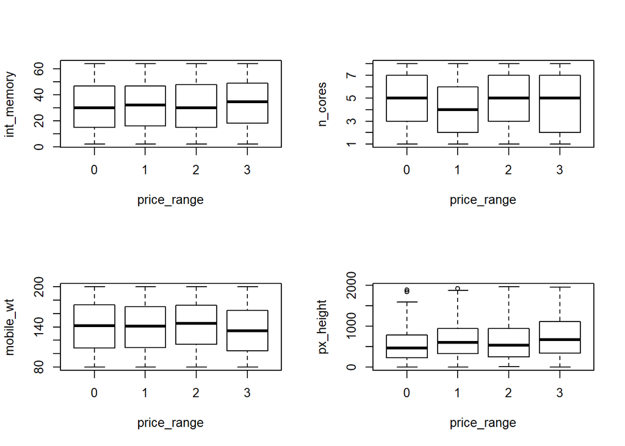

```r
#transfer numeric to factor
mobile$price_range<-as.factor(mobile$price_range)

attach(mobile)
par(mfrow=c(2,2))
boxplot(int_memory~price_range,xlab="price_range",ylab="int_memory")
boxplot(n_cores~price_range,xlab="price_range",ylab="n_cores")
boxplot(mobile_wt~price_range,xlab="price_range",ylab="mobile_wt")
boxplot(px_height~price_range,xlab="price_range",ylab="px_height")
```

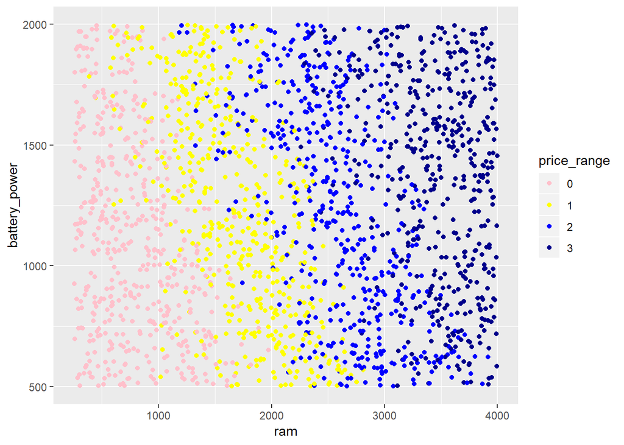

```r
par(mfrow=c(1,1))
require(ggplot2)
ggplot(mobile,aes(x=ram,y=battery_power,color=price_range))+
  scale_color_manual(values = c("pink","yellow","blue","darkblue"))+geom_point(size=1.5)
```

From above plots,we can see that only ram(*Random Access Memory*) has a positive correlationship with mobile price.

## Part 2

In this part, I split this data into two parts(training data & testing data) and to compare multinomial logistic regression and KNN.

```r
n<-nrow(mobile)
set.seed(9)
train<-sample(n,0.7*n)
mobile_tr<-mobile[train,]
mobile_te<-mobile[-train,]
prop.table(table(mobile_tr$price_range))
```

```
##
##         0         1         2         3
## 0.2500000 0.2571429 0.2542857 0.2385714
```

```r
require(nnet)
require(AER)
#(1)Multinomial Logistic Regression
logitfit<-multinom(price_range~.,data = mobile_tr)
coeftest(logitfit)
```

```
##
## z test of coefficients:
##
##                    Estimate  Std. Error     z value  Pr(>|z|)
## 1:(Intercept)   -8.9004e+02  1.4515e-03 -6.1320e+05 < 2.2e-16 ***
## 1:battery_power  2.1236e-01  2.6443e-02  8.0308e+00 9.683e-16 ***
## 1:blue           1.0404e+01  1.6171e-01  6.4340e+01 < 2.2e-16 ***
## 1:clock_speed    4.8987e+00  3.6938e-01  1.3262e+01 < 2.2e-16 ***
## 1:dual_sim      -5.6060e-02  1.4478e-01 -3.8720e-01 0.6985987
## 1:fc             3.5072e-01  2.6675e-01  1.3148e+00 0.1885759
## 1:four_g        -2.1571e+00  1.5883e-01 -1.3581e+01 < 2.2e-16 ***
## 1:int_memory     3.6504e-01  1.1203e-01  3.2584e+00 0.0011204 **
## 1:m_dep         -3.5606e+00  3.7755e-02 -9.4307e+01 < 2.2e-16 ***
## 1:mobile_wt     -3.3591e-01  3.5859e-01 -9.3680e-01 0.3488817
## 1:n_cores       -4.0399e-01  3.3868e-01 -1.1928e+00 0.2329336
## 1:pc             3.2280e-02  1.7342e-01  1.8610e-01 0.8523398
## 1:px_height      1.3293e-01  2.7756e-02  4.7891e+00 1.676e-06 ***
## 1:px_width       1.3007e-01  3.9390e-02  3.3021e+00 0.0009598 ***
## 1:ram            3.5373e-01  2.8935e-02  1.2225e+01 < 2.2e-16 ***
## 1:sc_h           4.1737e-01  2.0105e-01  2.0759e+00 0.0378989 *
## 1:sc_w           5.6311e-01  2.0364e-01  2.7652e+00 0.0056888 **
## 1:talk_time     -9.3985e-01  1.6899e-01 -5.5615e+00 2.674e-08 ***
## 1:three_g       -4.3483e-01  3.2891e-02 -1.3220e+01 < 2.2e-16 ***
## 1:touch_screen  -6.5266e+00  1.3131e-01 -4.9703e+01 < 2.2e-16 ***
## 1:wifi          -1.2086e+01  2.6052e-01 -4.6391e+01 < 2.2e-16 ***
## 2:(Intercept)   -1.7565e+03  3.4067e-03 -5.1560e+05 < 2.2e-16 ***
## 2:battery_power  3.7346e-01  2.6507e-02  1.4089e+01 < 2.2e-16 ***
## 2:blue           9.5028e+00  1.8242e-01  5.2094e+01 < 2.2e-16 ***
## 2:clock_speed    2.3311e+00  4.6645e-01  4.9975e+00 5.809e-07 ***
## 2:dual_sim       1.3549e+00  2.4903e-01  5.4406e+00 5.311e-08 ***
## 2:fc            -6.4280e-01  1.6878e-01 -3.8084e+00 0.0001399 ***
## 2:four_g        -3.4554e+00  2.9998e-01 -1.1519e+01 < 2.2e-16 ***
## 2:int_memory     6.3816e-01  9.2258e-02  6.9171e+00 4.609e-12 ***
## 2:m_dep         -1.5118e+01  5.2904e-02 -2.8577e+02 < 2.2e-16 ***
## 2:mobile_wt     -6.8237e-01  3.5962e-01 -1.8975e+00 0.0577664 .
## 2:n_cores       -1.3445e-01  1.9542e-01 -6.8800e-01 0.4914430
## 2:pc             1.5211e+00  1.1537e-01  1.3184e+01 < 2.2e-16 ***
## 2:px_height      2.1223e-01  2.7918e-02  7.6021e+00 2.914e-14 ***
## 2:px_width       2.3080e-01  3.9560e-02  5.8342e+00 5.404e-09 ***
## 2:ram            6.0602e-01  2.8897e-02  2.0972e+01 < 2.2e-16 ***
```

[output cut: 14 more lines]

```
## 3:m_dep         -4.2846e+00  5.3951e-02 -7.9417e+01 < 2.2e-16 ***
## 3:mobile_wt     -1.3175e+00  3.6193e-01 -3.6402e+00 0.0002724 ***
## 3:n_cores        1.5998e-01  2.7554e-01  5.8060e-01 0.5615139
## 3:pc             1.8561e+00  1.9519e-01  9.5093e+00 < 2.2e-16 ***
## 3:px_height      3.4293e-01  2.7975e-02  1.2258e+01 < 2.2e-16 ***
## 3:px_width       3.6199e-01  3.9616e-02  9.1375e+00 < 2.2e-16 ***
## 3:ram            9.5824e-01  2.8972e-02  3.3075e+01 < 2.2e-16 ***
## 3:sc_h           2.0868e+00  2.0198e-01  1.0332e+01 < 2.2e-16 ***
## 3:sc_w           1.0136e+00  2.4788e-01  4.0891e+00 4.330e-05 ***
## 3:talk_time     -1.0713e+00  1.2445e-01 -8.6085e+00 < 2.2e-16 ***
## 3:three_g       -5.7192e+00  2.9424e-02 -1.9437e+02 < 2.2e-16 ***
## 3:touch_screen  -1.4122e+01  1.7221e-01 -8.2003e+01 < 2.2e-16 ***
## 3:wifi          -2.7292e+01  3.4853e-01 -7.8308e+01 < 2.2e-16 ***
## ---
## Signif. codes:  0 '***' 0.001 '**' 0.01 '*' 0.05 '.' 0.1 ' ' 1
```

```r
logit_hat<-predict(logitfit,mobile_te)
t<-table(logit_hat,mobile_te$price_range,dnn=c("predicted","true"))
t
```

```
##          true
## predicted   0   1   2   3
##         0 149   4   0   0
##         1   1 135   7   0
##         2   0   1 135   3
##         3   0   0   2 163
```

```r
# misclassification rate
1-sum(diag(t))/sum(t)
```

```
## [1] 0.03
```

```r
#(2) KNN
require(class)
vars<-names(mobile) %in% c("price_range")
mobile_tr_x<-mobile_tr[!vars]
mobile_te_x<-mobile_te[!vars]
s.tr_x<-scale(mobile_tr_x)
s_te_x<-scale(mobile_te_x)
knn.pred <- knn(s.tr_x,s_te_x,mobile_tr$price_range,k=8,prob=TRUE)
t<-table(knn.pred,mobile_te$price_range,dnn=c("predicted","true"))
t
```

```
##          true
## predicted  0  1  2  3
##         0 94 42  5  0
##         1 45 59 49 10
##         2 11 35 63 69
##         3  0  4 27 87
```

```r
# misclassification rate
1-sum(diag(t))/sum(t)
```

```
## [1] 0.495
```

In above codes, I choose K=8, then I use **CV** to choose the best K and predict.

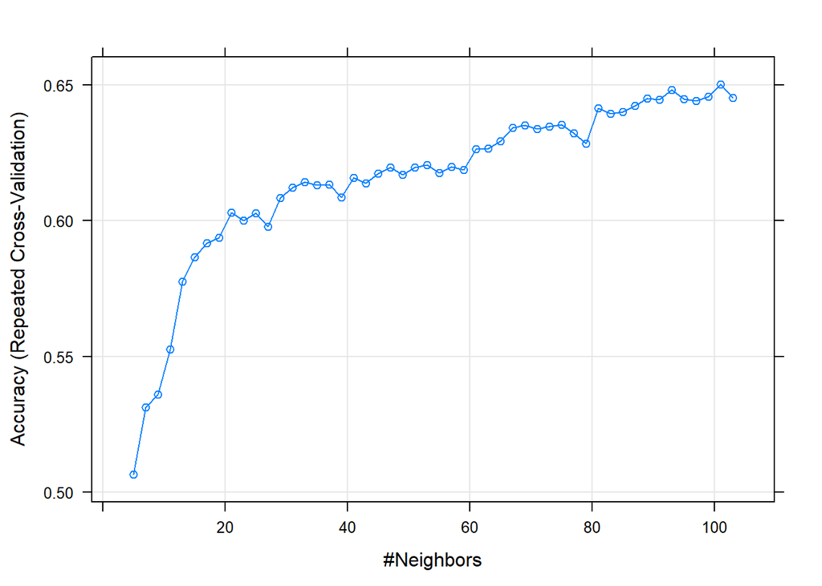

```r
require(caret)
knnfit<-train(price_range~.,data=mobile_tr,method="knn",
              trControl=trainControl(method="repeatedcv",repeats = 3),
              preProcess=c("center","scale"),tuneLength=50)
plot(knnfit)
```

```r
knnpred<-predict(knnfit,mobile_te)
t<-table(knnpred,mobile_te$price_range,dnn=c("predicted","true"))
t
```

```
##          true
## predicted   0   1   2   3
##         0 112  29   0   0
##         1  38  85  51   3
##         2   0  26  82  55
##         3   0   0  11 108
```

```r
# misclassification rate
1-sum(diag(t))/sum(t)
```

```
## [1] 0.355
```

Comparing the misclassification rate, we can find the **Multinomial Logistic Regression model** is better.The result of multinomial logistic regression shows that battery power, ram, camera pixel,and inter memory have significant positive relations with mobile price. And mobile depth, weight and charge time are inverse. The results are consistent with our common sense.

## Part 3

In this part, I choose **battery_power**, **ram** and **price_range** to take the multinomial logistic regression and visualize the decision boundaries.

```r
logitfit2<-multinom(price_range~ram+battery_power,data=mobile)
```

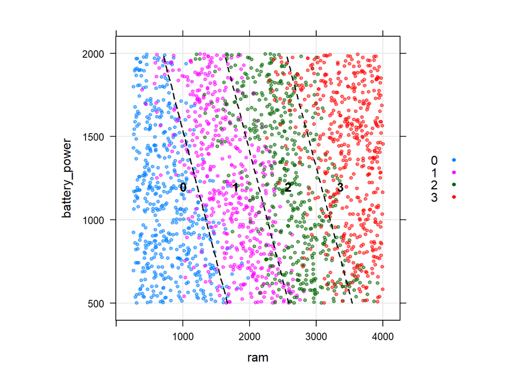

```r
x<-expand.grid(ram=pretty(ram,50),battery_power=pretty(battery_power,50))
logitfit_pr<-predict(logitfit2,x,type ="probs")
require(lattice)
fig2.main <- xyplot(battery_power ~ ram, groups=price_range,
                    auto.key=list(space="right"),
                    aspect=1, par.settings = simpleTheme(pch=20),grid=TRUE,alpha=.5)
diff1 <- apply(logitfit_pr, 1, function(x)x[1]-max(x[-1]))
diff2 <- apply(logitfit_pr, 1, function(x)x[2]-max(x[-2]))
diff3 <- apply(logitfit_pr, 1, function(x)x[3]-max(x[-3]))
diff4 <- apply(logitfit_pr, 1, function(x)x[4]-max(x[-4]))

fig2.addlayer1 <- latticeExtra::as.layer(
  contourplot(diff1 ~ ram*battery_power,data=x,at=0,labels="",lty=3,lwd=1.5), axes=FALSE)
fig2.addlayer2 <- latticeExtra::as.layer(
  contourplot(diff2 ~ ram*battery_power,data=x,at=0,labels="",lty=2,lwd=1.5), axes=FALSE)
fig2.addlayer3 <- latticeExtra::as.layer(
  contourplot(diff3 ~ ram*battery_power,data=x,at=0,labels="",lty=2,lwd=1.5), axes=FALSE)
fig2.addlayer4 <- latticeExtra::as.layer(
  contourplot(diff4 ~ ram*battery_power,data=x,at=0,labels="",lty=2,lwd=1.5), axes=FALSE)
fig2.main + fig2.addlayer1 + fig2.addlayer2 + fig2.addlayer3+fig2.addlayer4
trellis.focus("toplevel")
panel.text(0.35,0.5,"0",font=2)
panel.text(0.45,0.5,"1",font=2)
panel.text(0.55,0.5,"2",font=2)
panel.text(0.65,0.5,"3",font=2)
trellis.unfocus()
```

```r
detach(mobile)
```

## Reference

Mobile Price Classification, https://www.kaggle.com/iabhishekofficial/mobile-price-classification.